# データの可視化（ヒストグラム）

Sort

2021-01-21

この記事のコードをまとめたものは[Github](https://github.com/FruitGranola?tab=repositories)にあります。

# 使用するパッケージ

```r
library(tidyverse)
library(magrittr)
```

# ggplot2 の theme をあらかじめ設定しておく

```r
theme_set(theme_minimal(base_size = 15))
```

# 使用するデータ

```r
data <- read_csv("Data/House_of_Councilors_1996_2017.csv")
```

# データ内の変数名を確認する

```r
names(data)
```

```
 [1] "year"       "ku"         "kun"        "status"     "name"
 [6] "party"      "party_code" "previous"   "wl"         "voteshare"
[11] "age"        "nocand"     "rank"       "vote"       "eligible"
[16] "turnout"    "exp"        "expm"       "vs"         "exppv"
[21] "smd"        "party_jpn"
```

# 2005年にデータを絞る

```r
data_2005 <- data %>% filter(year == 2005) # 2005年のデータに絞る
```

# 上位4政党に絞る

今回は簡単のために上位4政党に絞る。

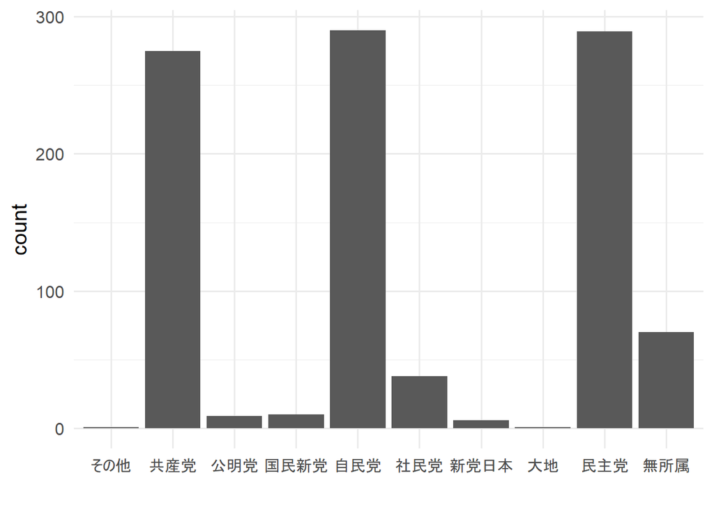

```r
data_2005 %>%
  ggplot(aes(x = party_jpn)) +
  geom_bar() +
  labs(x = "")
```

```r
data_2005 %<>% filter(party_jpn %in% c("自民党", "民主党", "社民党", "共産党"))
```

階級の幅を決めるときに、スタージェスの公式というものを使うらしい…

```r
# スタージェスの公式: k (階級の数) = 1 + log₂n (n = データ数)
bw <- round(1 + log2(count(data_2005)), 0) %>% as.integer()
```

# ヒストグラム

## 何の変哲もないヒストグラム

exppv: 候補者が有権者1人あたりに使う選挙費用

右方向に裾野が広がっていることがわかる。

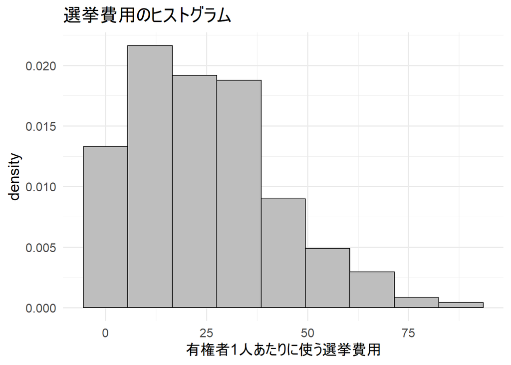

```r
data_2005 %>%
  ggplot(., aes(x = exppv)) +
  geom_histogram(aes(y = ..density..),
                 binwidth = bw,
                 color = "black", fill = "grey") +
  labs(x = "有権者1人あたりに使う選挙費用", title = "選挙費用のヒストグラム")
```

## 各政党ごとに確率密度を描写する

政党ごとに確率密度を見ることで、歪みの原因を特定できる。  
今回は共産党と社民党が歪みの原因のように見える。政党の大きさで選挙費用に差が出るのだろう。  
ヒストグラムを細かく見ることで、クラスタごとの特性を把握することができる。  
散布図を作る際に層化してみると、傾きに違いが出るかもしれない。

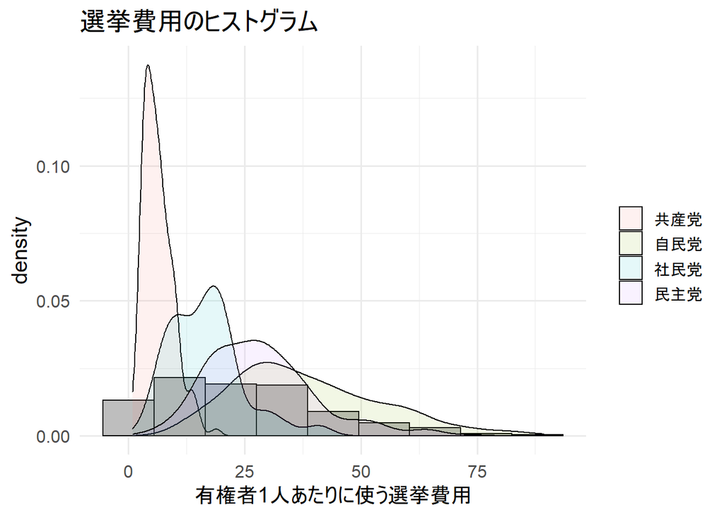

```r
data_2005 %>%
  ggplot(aes(x = exppv)) +
  geom_histogram(aes(y = ..density..),
                 binwidth = bw,
                 color = "black", fill = "grey") +
  geom_density(aes(fill = party_jpn), alpha = .1) +
  labs(x = "有権者1人あたりに使う選挙費用", title = "選挙費用のヒストグラム") +
  theme(legend.title = element_blank())
```

## 政党ごとに層化した散布図

層化した散布図を見ると、自民党・民主党グループ、共産党・社民党グループで選挙費用が得票率に与える影響が違うことが分かる。  
自民党と民主党: 傾きが小さい  
共産党と社民党: 傾きが大きい

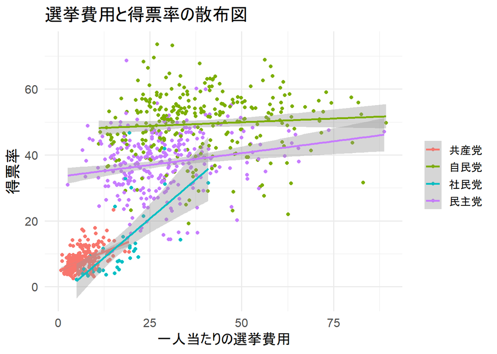

```r
data_2005 %>%
  ggplot(aes(x = exppv, y = voteshare, color = party_jpn)) +
  geom_point() +
  geom_smooth(method = "lm") +
  labs(x = "一人当たりの選挙費用", y = "得票率", title = "選挙費用と得票率の散布図") +
  theme(legend.title = element_blank())
```